# Duff and litter: Pre- and post-Tubbs fire

Morgan Gray

2022-11-09

## Overview

The aim of this research was to understand the impact of of the 2017 Tubbs fire on fuel loads. The objective of this research was to evaluate the impact of the 2017 Tubbs fire on duff and litter fuel loads over time. To meet this objective, we compared the pre- and post-fire levels of duff and litter at nine long-term vegetation monitoring plots. Surveys were conducted at four time points: 2016 (1y pre-fire), 2017 (0y post-fire), 2019 (2y post-fire), and 2021 (4y post-fire). We conducted surveys along two transects per plot; each transect had two quadrats. As a result, each time point had 36 data points: 9 plots x 2 transects x 2 quadrats.

Using the duff and litter data set as input, we asked the following questions:

1. Did the total fuel load (all duff and litter combined) differ between years?
2. Did fuel load differ between years for duff and/or litter? If so, which years were different?

#### Fuel measurements for duff and litter depth

We answered these questions using a time series of plot-level data for (1) the total amount of duff and litter and (2) the mean amount of each fuel class (duff, litter). We defined “total (or all) duff and litter” as the combined total of the duff and litter within a plot.

We calculated the *plot-level mean for each fuel class* to account for replicate surveys within each plot. To calculated the the *plot-level total* at each time point, we summed the plot means for all fuel classes by fuel type.

Below is a table that shows the plot-level mean at each time point for litter and duff (total and mean by fuel class).

| fuel_class | plot_id | metric | units | 2016 | 2017 | 2019 | 2021 |
| --- | --- | --- | --- | --- | --- | --- | --- |
| All | RxF01 | total | cm | 4.445 | 1.714 | 3.842 | 4.540 |
| All | RxF02 | total | cm | 10.001 | 2.445 | 8.477 | 1.841 |
| All | RxF03 | total | cm | 7.620 | 4.413 | 1.397 | 1.143 |
| All | RxF04 | total | cm | 6.668 | 1.746 | 3.937 | 3.651 |
| All | RxF05 | total | cm | 4.127 | 0.953 | 6.096 | 1.016 |
| All | RxF06 | total | cm | 7.652 | 1.302 | 9.970 | 1.365 |
| All | RxF07 | total | cm | 11.748 | 1.810 | 4.318 | 3.111 |
| All | RxF08 | total | cm | 8.731 | 1.048 | 2.699 | 3.080 |
| All | RxF09 | total | cm | 10.160 | 1.238 | 1.810 | 1.429 |
| Duff | RxF01 | mean | cm | 2.857 | 0.794 | 0.603 | 0.254 |
| Duff | RxF02 | mean | cm | 3.969 | 1.270 | 0.064 | 0.254 |
| Duff | RxF03 | mean | cm | 2.699 | 1.746 | 0.127 | 0.286 |
| Duff | RxF04 | mean | cm | 3.651 | 1.238 | 0.286 | 1.270 |
| Duff | RxF05 | mean | cm | 2.540 | 0.603 | 0.064 | 0.254 |
| Duff | RxF06 | mean | cm | 5.239 | 1.111 | 0.444 | 0.254 |
| Duff | RxF07 | mean | cm | 6.033 | 1.270 | 0.349 | 0.254 |
| Duff | RxF08 | mean | cm | 5.080 | 0.857 | 0.000 | 0.254 |
| Duff | RxF09 | mean | cm | 3.810 | 1.111 | 0.000 | 0.254 |
| Litter | RxF01 | mean | cm | 1.587 | 0.921 | 3.239 | 4.286 |
| Litter | RxF02 | mean | cm | 6.032 | 1.175 | 8.414 | 1.587 |
| Litter | RxF03 | mean | cm | 4.921 | 2.667 | 1.270 | 0.857 |
| Litter | RxF04 | mean | cm | 3.016 | 0.508 | 3.651 | 2.381 |
| Litter | RxF05 | mean | cm | 1.587 | 0.349 | 6.032 | 0.762 |
| Litter | RxF06 | mean | cm | 2.413 | 0.190 | 9.525 | 1.111 |
| Litter | RxF07 | mean | cm | 5.715 | 0.540 | 3.969 | 2.857 |
| Litter | RxF08 | mean | cm | 3.651 | 0.190 | 2.699 | 2.826 |
| Litter | RxF09 | mean | cm | 6.350 | 0.127 | 1.810 | 1.175 |

#### Statistical methods

Statistically significant differences were identified using repeated measures analysis of variance (ANOVA) and post hoc comparisons. P-values were adjusted using the Bonferroni multiple testing correction method.

The repeated-measures ANOVA is used for analyzing data where same subjects are measured more than once. This test is also referred to as a within-subjects ANOVA or ANOVA with repeated measures. The “within-subjects” term means that the same individuals (here, individuals are plots) are measured on the same outcome variable under different time points. The main goal of a repeated measures ANOVA is to evaluate if there is a statistically significant interaction effect between within-subjects factors in explaining a continuous outcome variable. The repeated measures ANOVA makes the following assumptions about the data:

- No significant outliers in any cell of the design
- Normality: the outcome (or dependent) variable should be approximately normally distributed in each cell of the design
- Assumption of sphericity: the variance of the differences between groups should be equal

We assessed outliers using the the interquartile range (IQR; IQR = Q3 - Q1). Values above Q3 + 1.5xIQR or below Q1 - 1.5xIQR are considered as outliers. Values above Q3 + 3xIQR or below Q1 - 3xIQR are considered as extreme points (or extreme outliers). Q1 and Q3 are the first and third quartile, respectively. Extreme outliers can be due to data entry errors, measurement errors, or unusual values. The outlier may be included if one believes the result will not be substantially affected; this can be evaluated by comparing the result of the ANOVA with and without the outlier.

We assessed normality by visual inspection of a QQ plot for each time point. A QQ plot draws the correlation between a given data and the normal distribution. We also conducted the Shapiro-Wilk test for each time point. Using this method, normally distributed data will have p-value >0.05.

The assumption of sphericity was checked during the computation of the ANOVA test using the R function anova_test() [rstatix package]. The Mauchly’s test was internally used to assess the sphericity assumption, and the Greenhouse-Geisser sphericity correction was automatically applied to factors violating the sphericity assumption.

#### Check assumptions

##### *Check for outliers*

There was one extreme outlier in the data set for total duff and litter (plot RxF03 in 2017). There were two extreme outliers in the mean by fuel class data set for duff (plots RxF03 and RxFO4 in 2021).

| fuel_class | metric | time | plot_id | si_value | units | is_outlier | is_extreme |
| --- | --- | --- | --- | --- | --- | --- | --- |
| all | total | 2017 | RxF03 | 4.413 | cm | TRUE | TRUE |
| duff | mean | 2021 | RxF03 | 0.286 | cm | TRUE | TRUE |
| duff | mean | 2021 | RxF04 | 1.270 | cm | TRUE | TRUE |

A QQ plot created using raw values showed one point for total (all) duff and litter in 2017 (red) that was distant from the reference line. As expected, two outlier values for duff in 2021 (yellow) strayed from the reference line.

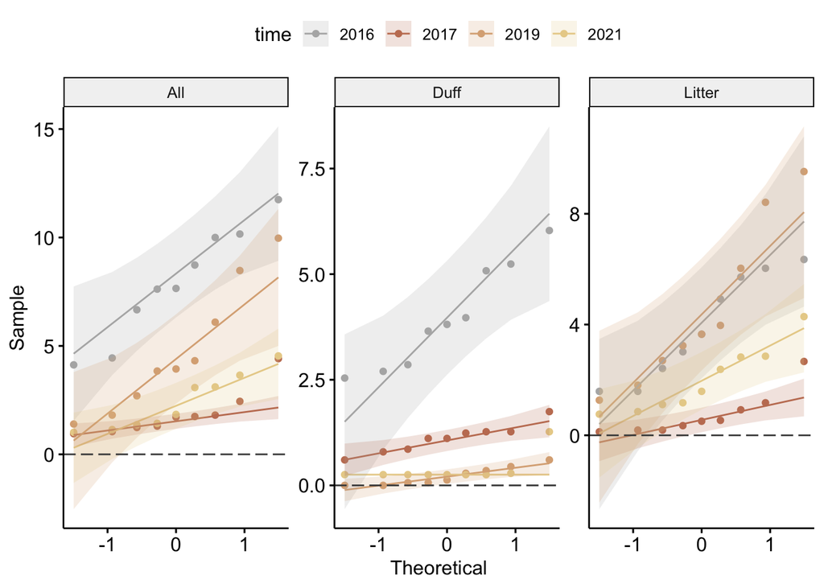

##### *Check for normality*

Total duff and litter load was normally distributed at each time point (p > 0.01), except for year 2017. Plot-level values by fuel class were normally distributed at each time point (p > 0.01), except for duff in 2021 and litter in 2017. Normality was assessed by Shapiro-Wilk’s test.

| fuel_class | time | is_normal | p | statistic |
| --- | --- | --- | --- | --- |
| all | 2017 | FALSE | 0.0094872 | 0.771 |
| litter | 2017 | FALSE | 0.0066324 | 0.758 |
| duff | 2021 | FALSE | 0.0000005 | 0.406 |

#### Identify the most appropriate transformation

We applied a series of transformations to each subset, then evaluated the resulting data for outliers and normality. To create the transformed subsets, we used scale() from base R and four normalization functions from the bestNormalize package: arcsinh_x, log_x, orderNorm, and sqrt_x.

The application of the arcsine and log functions resolved outliers within the subset for total fuels. Outliers within the Duff subset were not improved with any transformation.

| fuel_class | time | method | plot_id | number | is_outlier | is_extreme |
| --- | --- | --- | --- | --- | --- | --- |
| all | 2017 | value_arcsine | RxF03 | 0.3998317 | TRUE | FALSE |
| all | 2017 | value_log | RxF03 | 0.4250334 | TRUE | FALSE |

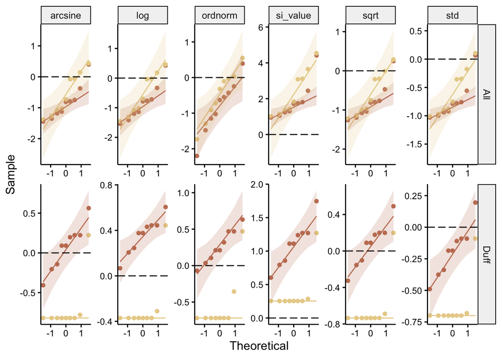

The application of the multiple transformations resulted in normally-distributed values for total fuels and litter in 2017; raw data for these two subsets were not normally distributed. The effective transformations for total fuels and litter included: arcsine, log, orderNorm, and square root. No transformation normalized the distribution of the Duff subset in 2021.

| fuel_class | time | value_arcsine | value_log | value_norm | value_ordnorm | value_sqrt |
| --- | --- | --- | --- | --- | --- | --- |
| all | 2017 | TRUE | TRUE | TRUE | TRUE | TRUE |
| litter | 2017 | TRUE | TRUE | TRUE | TRUE | TRUE |

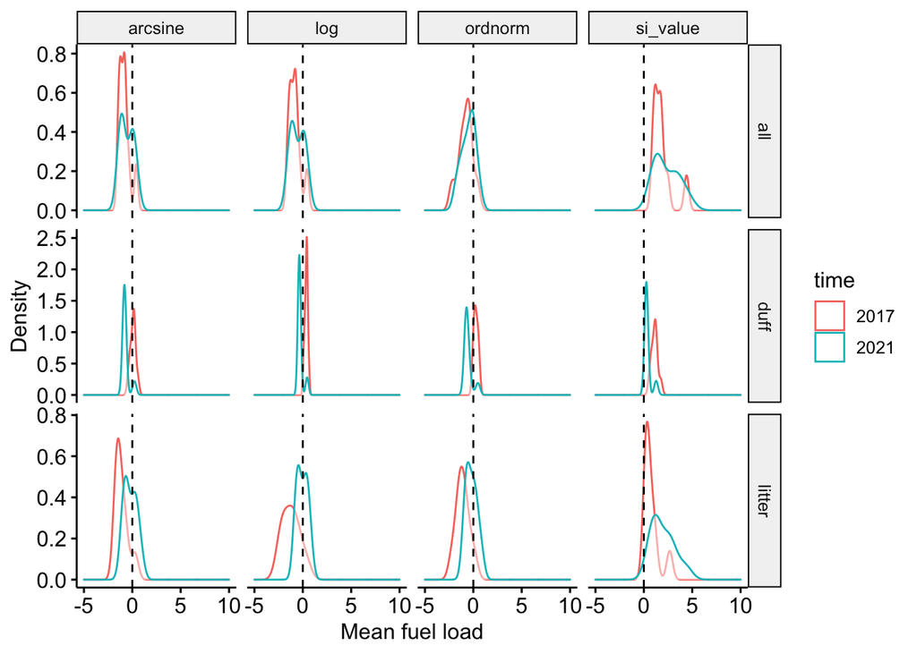

##### *Normalize and standardize data*

We transformed and standardized the plot-level values for total fuels and mean by fuel class by time point. We subset the plot-level values by fuel class (all, duff, litter), then applied an ordered quantile transformation to normalize the values, calculated as:

g(x) = psi^-1 * ((rank(x) - .5) / (length(x)))

## Total fuel load

### Summary statistics for total fuel load by year

The following table summarizes the plot-level total amount of duff and litter for each time point.

| fuel_class | time | units | mean | sd | n |
| --- | --- | --- | --- | --- | --- |
| All | 2016 | cm | 7.906 | 2.570 | 9 |
| All | 2017 | cm | 1.852 | 1.065 | 9 |
| All | 2019 | cm | 4.727 | 2.931 | 9 |
| All | 2021 | cm | 2.353 | 1.271 | 9 |

### Visualization of total fuel load by year

The visual inspection of a box plot of total duff and litter by year showed lower values in post-fire years. Specifically, we observed a decrease in the depth of all duff and litter immediately following the fire (2017; 0-y post-fire). The mean depth of duff and litter did not return to pre-fire levels in subsequent years.

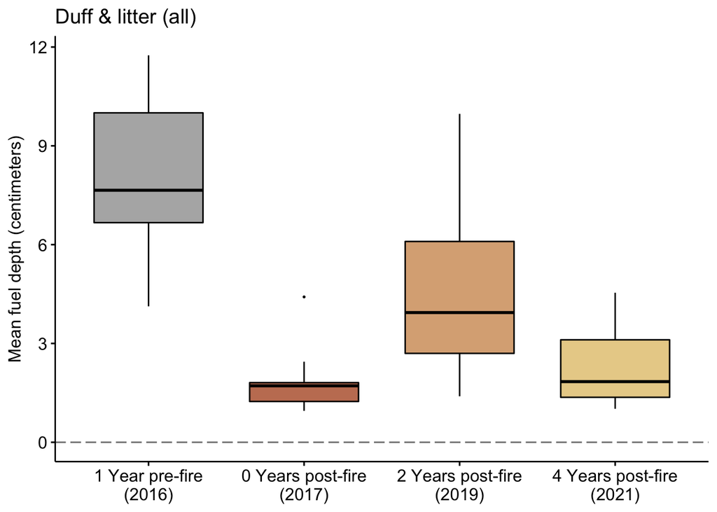

### Main effect of year on total fuel load

We conducted a one-way repeated measures ANOVA to test for a main effect of year on fuel load (i.e., whether total fuel load was significantly different between the four time points). We found a significant effect of year on total fuel load F(3, 24) = 14.413, p-adj. = 1.41e-05, ges = 0.554.

| fuel_class | method | effect | p_adj | p_adj_sig | statistic | d_fn | d_fd | ges | index_value |
| --- | --- | --- | --- | --- | --- | --- | --- | --- | --- |
| All | me | time | 1.41e-05 | *** | 14.413 | 3 | 24 | 0.554 | value_norm |

### Pairwise comparison of total fuel load between years

Because we found a significant effect of year, we conducted a post hoc pairwise comparison in total fuel load between years. We found a significant difference in total fuel load between 2016 and 2017 (p-adj. <0.001) and 2021 (p-adj <0.01).

| fuel_class | method | group1 | group2 | p_adj | p_adj_sig | statistic | df | index_value |
| --- | --- | --- | --- | --- | --- | --- | --- | --- |
| All | pwc | 2016 | 2017 | 0.000834 | *** | 6.793 | 8 | value_norm |
| All | pwc | 2016 | 2021 | 0.002000 | ** | 5.787 | 8 | value_norm |
| All | pwc | 2017 | 2019 | 0.147000 | n.s. | -2.764 | 8 | value_norm |
| All | pwc | 2016 | 2019 | 0.169000 | n.s. | 2.676 | 8 | value_norm |
| All | pwc | 2019 | 2021 | 0.341000 | n.s. | 2.224 | 8 | value_norm |
| All | pwc | 2017 | 2021 | 1.000000 | n.s. | -1.054 | 8 | value_norm |

## Mean fuel load, by fuel class

### Summary statistics for mean fuel load by fuel class and year

The following table summarizes the plot-level mean values for the two fuel classes (duff, litter) at each time point.

| fuel_class | time | units | mean | sd | n |
| --- | --- | --- | --- | --- | --- |
| duff | 2016 | cm | 3.986 | 1.231 | 9 |
| duff | 2017 | cm | 1.111 | 0.334 | 9 |
| duff | 2019 | cm | 0.215 | 0.216 | 9 |
| duff | 2021 | cm | 0.370 | 0.337 | 9 |
| litter | 2016 | cm | 3.919 | 1.892 | 9 |
| litter | 2017 | cm | 0.741 | 0.803 | 9 |
| litter | 2019 | cm | 4.512 | 2.881 | 9 |
| litter | 2021 | cm | 1.982 | 1.187 | 9 |

### Visualization of mean fuel load by fuel class and year

A visual inspection of box plots for mean fuel depth by year showed differing post-fire trends between the duff and litter fuel classes. Although duff and litter both showed a decrease in depth immediately following the fire (2017, 0-y post-fire; red), the subsequent annual trends differed. The temporal trend for total duff and litter was more similar to that of the litter fuel class, and showed less similarity to that of the duff fuel class. These results suggest that litter was an influential driver of the post-fire patterns observed for duff and litter as a group.

**Duff**  
– Duff depth remained low in all post-fire years.  
– Values in 2019 (orange) and 2021 (yellow) were lower than those for 2017 (red).

**Litter**  
– Litter depth returned to pre-fire levels 2-y after the fire (2019, orange), then showed a second decrease in 2021 (4-y post-fire, yellow).  
– This post-fire increase and decrease in litter depth was similar to the temporal trend observed for duff and litter overall.

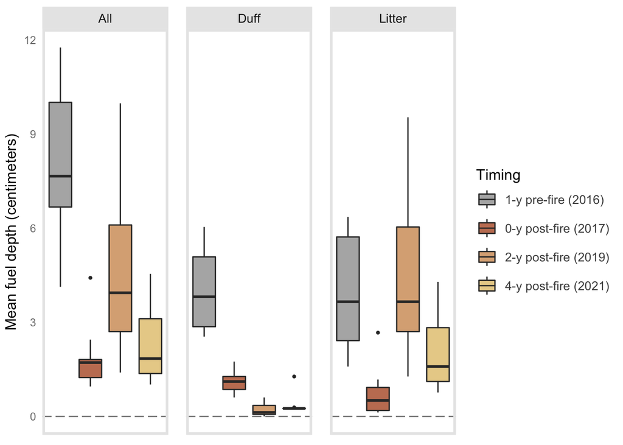

### Interaction between year and fuel class

We investigated whether there was a significant change in the plot-level fuel load over time when accounting for fuel class (duff, litter). A two-way repeated measures ANOVA was used to determine whether there was a significant interaction between year and fuel class on mean fuel load. Here, the effect of year on fuel load was our focal variable of primary concern. However, the effect of year may differ between duff and litter, so fuel_class was considered a moderator variable.

There was a statistically significant two-way interaction between fuel clas and year, F(3, 24) = 26.727, p-adj. = 2.397e-07, ges = 0.506. A significant two-way interaction indicates that the impact of fuel class on fuel load depends on year (and vice versa).

| method | effect | p_adj | p_adj_sig | statistic | d_fn | d_fd | ges | index_value |
| --- | --- | --- | --- | --- | --- | --- | --- | --- |
| interaction | time:fuel_class | 2e-07 | *** | 26.727 | 3 | 24 | 0.506 | value_norm |

### Effect of year on each fuel class

Because we found a significant interaction between fuel class and year, we conducted a main effect assessment for each fuel class.

We found a significant main effect of year on fuel load for both fuel classes at a signficance level of <0.001.

| fuel_class | method | effect | p_adj | p_adj_sig | statistic | d_fn | d_fd | ges | index_value |
| --- | --- | --- | --- | --- | --- | --- | --- | --- | --- |
| duff | me | time | 0.0000000 | *** | 39.225 | 3 | 24 | 0.762 | value_norm |
| litter | me | time | 0.0001138 | *** | 11.899 | 3 | 24 | 0.556 | value_norm |

### Pairwise comparisons of mean fuel load between years, by fuel class

The pre-fire fuel load (2016) was significantly different from that in 2017 for both fuel classes (duff: p <0.001; litter: p < 0.01). For each fuel class, we found a significant difference in mean fuel load between the years for the following comparisons:

**Duff**

- 2016 and 2019, 2021, 2017 (p-adj < 0.001)
- 2017 and 2019, 2021 (p-adj < 0.01)
- A pairwise comparison between years showed that the mean duff depth was significantly different between all years except 2019/2021.

**Litter**

- 2017 and 2016, 2019 (p-adj < 0.01)

| fuel_class | method | group1 | group2 | p_adj | p_adj_sig | statistic | df | index_value |
| --- | --- | --- | --- | --- | --- | --- | --- | --- |
| duff | pwc | 2016 | 2019 | 0.000155 | *** | 8.599 | 8 | value_norm |
| duff | pwc | 2016 | 2021 | 0.000356 | *** | 7.664 | 8 | value_norm |
| duff | pwc | 2016 | 2017 | 0.001000 | *** | 6.294 | 8 | value_norm |
| duff | pwc | 2017 | 2021 | 0.002000 | ** | 6.040 | 8 | value_norm |
| duff | pwc | 2017 | 2019 | 0.008000 | ** | 4.784 | 8 | value_norm |
| duff | pwc | 2019 | 2021 | 0.846000 | n.s. | -1.634 | 8 | value_norm |
| litter | pwc | 2016 | 2017 | 0.004000 | ** | 5.387 | 8 | value_norm |
| litter | pwc | 2017 | 2019 | 0.008000 | ** | -4.847 | 8 | value_norm |
| litter | pwc | 2017 | 2021 | 0.085000 | n.s. | -3.128 | 8 | value_norm |
| litter | pwc | 2016 | 2021 | 0.204000 | n.s. | 2.554 | 8 | value_norm |
| litter | pwc | 2019 | 2021 | 0.209000 | n.s. | 2.536 | 8 | value_norm |
| litter | pwc | 2016 | 2019 | 1.000000 | n.s. | -0.395 | 8 | value_norm |